# EAD Research on Bike Market

Kunpeng Yang

2/17/2019

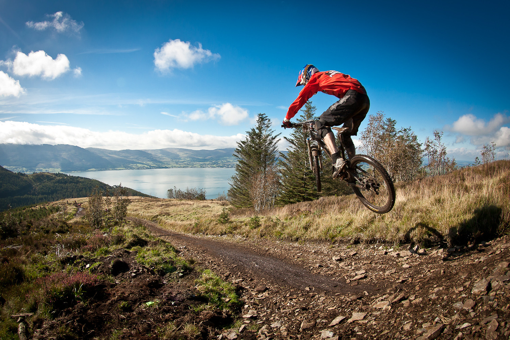

bike

link to the Github repository: [Kunpeng Yang EDA project](https://github.com/Zlisu/EDA)

## 1. Purpose and Questions

This project researches on the bike market. We will gain insights on valubale information of bike’s market by investigate on bike’s features, price and market shares. The research is conducted in EDA approach. We raised questions of our interest and answered the question by conducting analysis on the data we have.

Questions:

1. Which is the best selling bike model among all stores?
2. Which type of bikes (Mountain vs Road) is more expensive?
3. Does the material of the bikes has influence on price?
4. Is price predictive of market share?

## 2. Describe data

Let’s take a first look at the dataset, and find out what fileds we got

```r
# set working directory
setwd("/Users/birdfish/Documents/GitHub/EDA")
# import data into variable df
df <- read.csv("Data/bikeVendors.csv")
# view top 10 rows
library(dplyr)
top_n(df, 5)
```

```
##                             model category1      category2    frame price
## 1                       Fat CAAD1  Mountain       Fat Bike Aluminum  3730
## 2       Slice Hi-Mod Dura Ace D12      Road     Triathalon   Carbon  4500
## 3  Supersix Evo Hi-Mod Dura Ace 1      Road     Elite Road   Carbon  7990
## 4      Supersix Evo Hi-Mod Utegra      Road     Elite Road   Carbon  4260
## 5 Synapse Carbon Disc Ultegra D12      Road Endurance Road   Carbon  4800
##   Albuquerque.Cycles Ann.Arbor.Speed Austin.Cruisers Cincinnati.Speed
## 1        0.013986014     0.001661130     0.004065041      0.002557545
## 2        0.006993007     0.013289037     0.008130081      0.020460358
## 3        0.000000000     0.013289037     0.004065041      0.007672634
## 4        0.006993007     0.008305648     0.020325203      0.023017903
## 5        0.003496503     0.016611296     0.000000000      0.017902813
##   Columbus.Race.Equipment Dallas.Cycles Denver.Bike.Shop Detroit.Cycles
## 1             0.007614213   0.000000000      0.009561060    0.003968254
## 2             0.012690355   0.008547009      0.000869187    0.001984127
```

[output cut: 45 more lines]

```r
# Add a column which is the average market share among all stores of a certain bike
library(tidyverse)
df <- df %>%
  mutate(Avg = select(., Albuquerque.Cycles:Wichita.Speed) %>% rowSums(na.rm = TRUE)/30)

levels(df$category1)
```

```
## [1] "Mountain" "Road"
```

```r
levels(df$category2)
```

```
## [1] "Cross Country Race" "Cyclocross"         "Elite Road"
## [4] "Endurance Road"     "Fat Bike"           "Over Mountain"
## [7] "Sport"              "Trail"              "Triathalon"
```

```r
levels(df$frame)
```

```
## [1] "Aluminum" "Carbon"
```

So we have 35 fields in total. * The first column ‘model’ is the bike’s model. Each row respresents one model of bikes. * The second column ‘category1’ represents the types of the bike: “Mountain” or “Road” * The third column ‘category2’ categorize bikes into more detailed types, including Cross Country Race, Cyclocross, Fat Bike, etc. * The fourth column ‘frame’ represents the material of which the bike’s frame is made: Aluminum or Carbon. * The fifth column ‘price’ is the bike’s price * The 6th to 35th columns represents names of bike stores. In these columns, each cell is the market share of a certain bike (indicated by the row) in a certain store (indicated by the column).

Then let’s take a look of the data type of each columns

```r
str(df)
```

```
## 'data.frame':    97 obs. of  36 variables:
##  $ model                       : Factor w/ 97 levels "Bad Habit 1",..: 1 2 3 4 5 6 7 8 9 10 ...
##  $ category1                   : Factor w/ 2 levels "Mountain","Road": 1 1 1 1 1 2 2 2 2 2 ...
##  $ category2                   : Factor w/ 9 levels "Cross Country Race",..: 8 8 8 8 8 3 3 3 3 3 ...
##  $ frame                       : Factor w/ 2 levels "Aluminum","Carbon": 1 1 1 1 1 1 1 1 1 1 ...
##  $ price                       : int  3200 2660 2770 2130 1620 2660 1680 5860 1950 4260 ...
##  $ Albuquerque.Cycles          : num  0.01748 0.00699 0.01049 0.01049 0.0035 ...
##  $ Ann.Arbor.Speed             : num  0.00664 0.00997 0.01495 0.00997 0.00332 ...
##  $ Austin.Cruisers             : num  0.00813 0.00407 0.00813 0.00813 0 ...
##  $ Cincinnati.Speed            : num  0.00512 0 0 0 0 ...
##  $ Columbus.Race.Equipment     : num  0.01015 0 0 0.00508 0.00254 ...
##  $ Dallas.Cycles               : num  0.01282 0.01709 0.00427 0.00427 0.00427 ...
##  $ Denver.Bike.Shop            : num  0.0117 0.0139 0.0183 0.0152 0.0169 ...
##  $ Detroit.Cycles              : num  0.00992 0.01587 0.0119 0.00595 0.0119 ...
##  $ Indianapolis.Velocipedes    : num  0.00627 0.00313 0.0094 0.0094 0 ...
```

[output cut: 22 more lines]

model, category1, category2 and frame are factors because these are categorical data. Price is in int and the market shares in each stores is in num. The data type is correct so we don’t need to convert.

## 3. Explore data

### 3.1 numbers by category

```r
table(df$category1)
```

```
##
## Mountain     Road
##       51       46
```

```r
table(df$category2)
```

```
##
## Cross Country Race         Cyclocross         Elite Road
##                 19                  4                 21
##     Endurance Road           Fat Bike      Over Mountain
##                 16                  2                  8
##              Sport              Trail         Triathalon
##                  9                 13                  5
```

```r
table(df$frame)
```

```
##
## Aluminum   Carbon
##       40       57
```

We have 97 models of bikes in total. If we group them by category1, we can see there are 51 mountain bikes and 46 road bikes. If we group them by category2, we have 19 Cross Country Race bikes, 4 Cyclocross bikes, 21 Elite Road bikes, 16 Endurace Road bikes, 2 Fat Bikes, 8 Over Mountain bikes, 9 Sport bikes, 13 Trail bikes and 5 Triathalon.

### 3.2 price

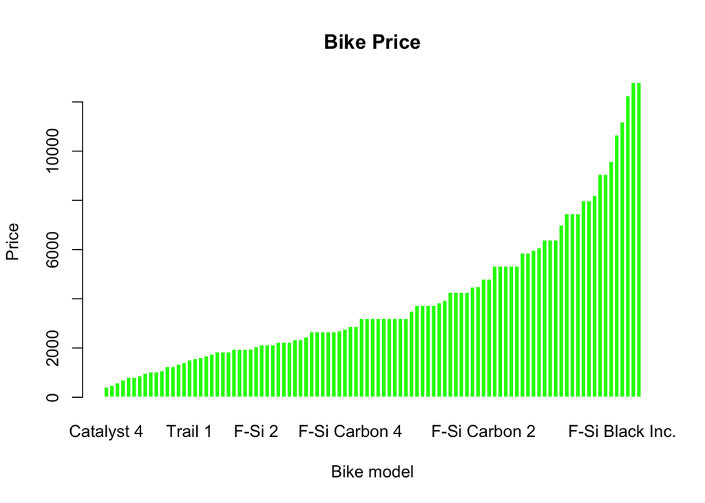

```r
df1 <- df[order(df$price),] # sort data by price
barplot(df1$price, names.arg=df1$model, xlab = "Bike model", ylab = "Price",
        main = "Bike Price", col = "green", border = "white")
```

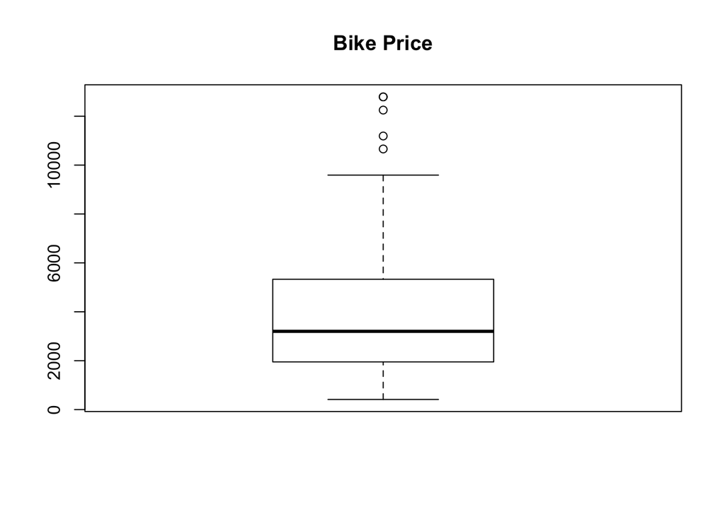

```r
boxplot(df$price, main = "Bike Price")
```

It looks like the variance of bike price is quite large. Based on the box plot, the median is slightly above 3100, while the 1st and 3rd quantiles are about 2000 and 5500 respectively. There are also some very large data points. These could be outliers. We can confirm our obervation by doing the calculations below:

```r
mean(df$price)
```

```
## [1] 3953.763
```

```r
quantile(df$price)
```

```
##    0%   25%   50%   75%  100%
##   415  1950  3200  5330 12790
```

We can also compare the average price of Mountain bikes to Road bikes

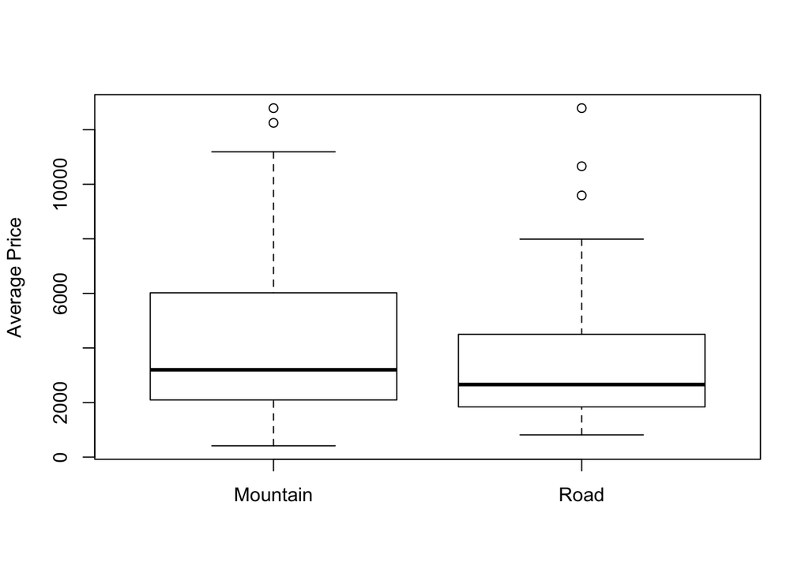

```r
# Mountain bike vs Road bike
boxplot(df$price~df$category1, ylab = "Average Price")
```

From the plot we can see mountain bikes price is higher than road bike on average.

Also we can get some statics of the price by group:

```r
library(pastecs)
by(df$price, df$category1, stat.desc, basic = FALSE, norm = TRUE)
```

```
## df$category1: Mountain
##       median         mean      SE.mean CI.mean.0.95          var
## 3.200000e+03 4.255294e+03 4.260223e+02 8.556909e+02 9.256243e+06
##      std.dev     coef.var     skewness     skew.2SE     kurtosis
## 3.042408e+03 7.149700e-01 1.007152e+00 1.510136e+00 4.269827e-01
##     kurt.2SE   normtest.W   normtest.p
## 3.254836e-01 9.092598e-01 8.698062e-04
## --------------------------------------------------------
## df$category1: Road
##       median         mean      SE.mean CI.mean.0.95          var
## 2.660000e+03 3.619457e+03 3.926837e+02 7.909056e+02 7.093222e+06
##      std.dev     coef.var     skewness     skew.2SE     kurtosis
## 2.663310e+03 7.358316e-01 1.573396e+00 2.247091e+00 2.179999e+00
##     kurt.2SE   normtest.W   normtest.p
## 1.585159e+00 8.287368e-01 8.996042e-06
```

We can see that Mountain bikes have higher median and mean than Road bikes in term of price. The price of mountain bike also has higher standard deviation.

### 3.3 average market share

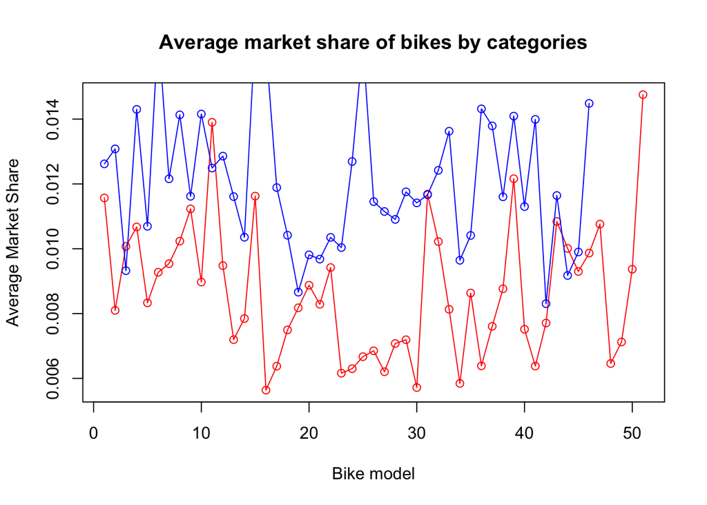

```r
# select mountain bikes
mountain <- subset(x = df, subset = category1 == "Mountain")
# select road bikes
road <- subset(x = df, subset = category1 == "Road")
# plot mountain bike mkt shares
plot(mountain$Avg, type = "o", col = "red", xlab = "Bike model", ylab = "Average Market Share",
     main = "Average market share of bikes by categories")
# add line of road bike shares
lines(road$Avg, type = "o", col = "blue")
```

Average market share of different bike models varies a lot. It looks like the market shares of road bikes (blue) is larger than mountain bikes (red) in general. Let’s confirm that by box plot:

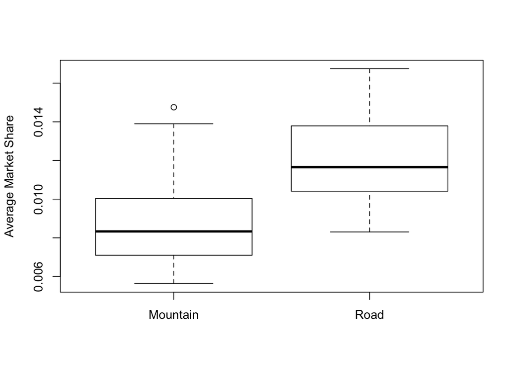

```r
boxplot(df$Avg ~ df$category1, ylab = "Average Market Share")
```

### 3.4 clusters

We can find out which models are more similar to each other by grouping them into several clusters. To do this we first needs to calculte the optimal number of clusters, and then group similar observations and plot.

```r
library(cluster)
library(factoextra)
```

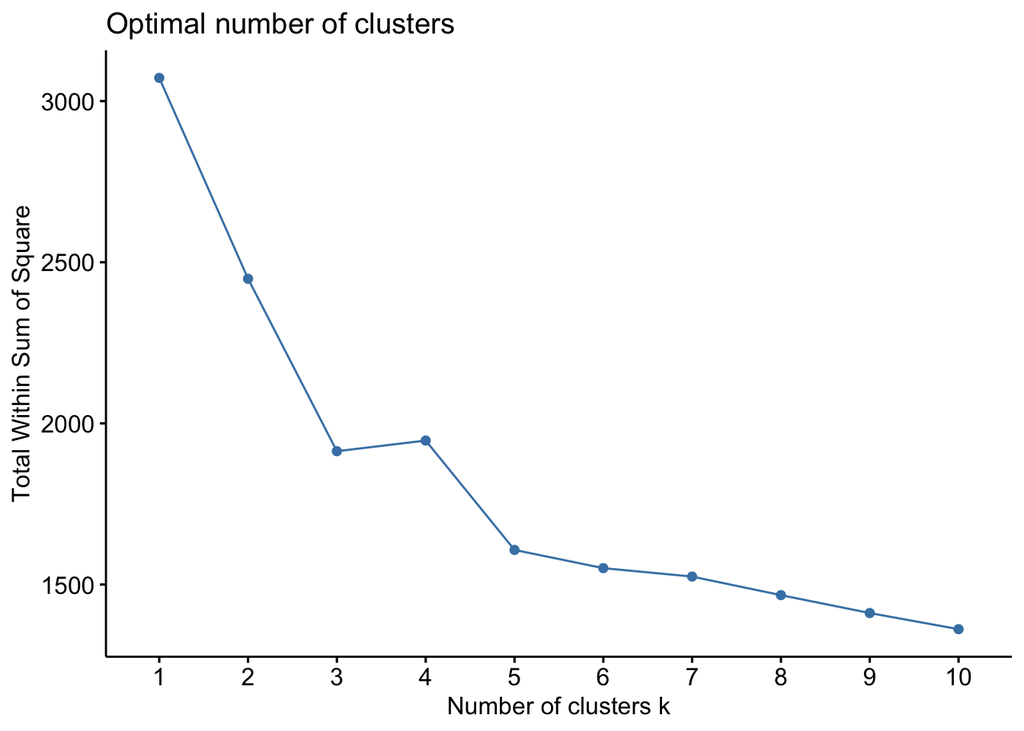

```r
# drop categorial data fields
drops <- c("model", "category1", "category2", "frame")
bike2 <- df
bike2 <- bike2[, !(names(bike2) %in% drops)]

# use bike models as row names
bike_model <- df$model
row.names(bike2) <- bike_model

bike2$price <- as.numeric(bike2$price)

bike2 <- na.omit(bike2) # remove missing value
bike2 <- scale(bike2) # scaling to avoid influence of unit

set.seed(123)

fviz_nbclust(bike2, kmeans, method = "wss")
```

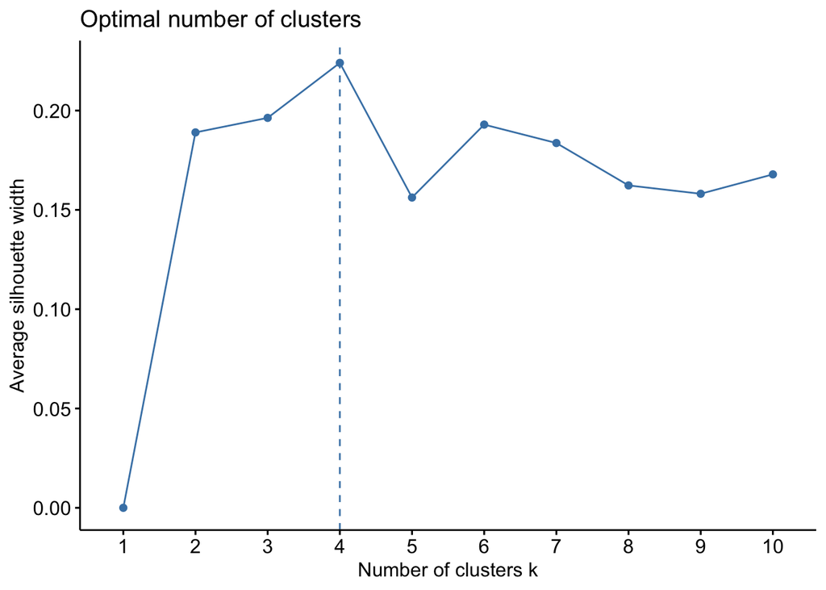

```r
# Average Silhousette Method
fviz_nbclust(bike2, kmeans, method = "silhouette")
```

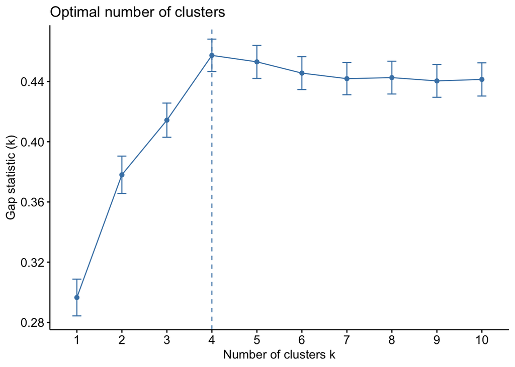

```r
# Gap Statistic Method
gap_stat <- clusGap(bike2, FUN = kmeans, nstart = 25,
                    K.max = 10, B = 50)
fviz_gap_stat(gap_stat)
```

From the plot we know 4 is the optimal number of clusters. We will do k-means by 4 groups.

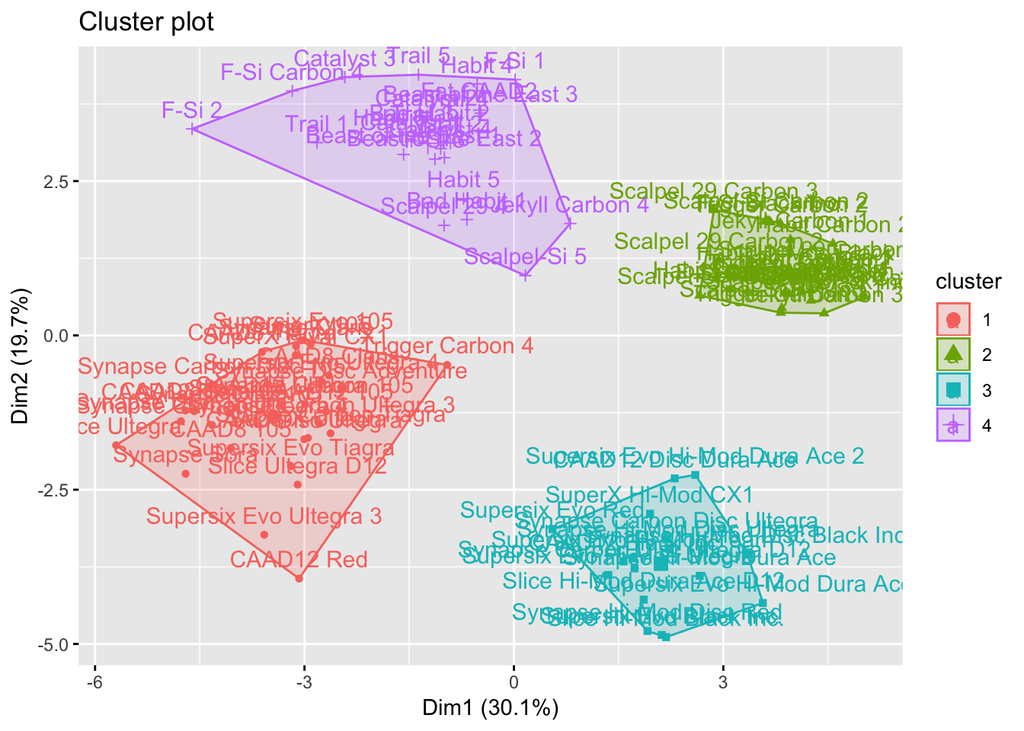

```r
k4 <- kmeans(bike2, centers = 4, nstart = 25)
fviz_cluster(k4, data = bike2)
```

## 4. Analysis

### 4.1. Which type of bikes has higher average price?

To answer this question, we need to perform a t-test. First step is to test the assumption. The dependent variable (price) should be normally distributed:

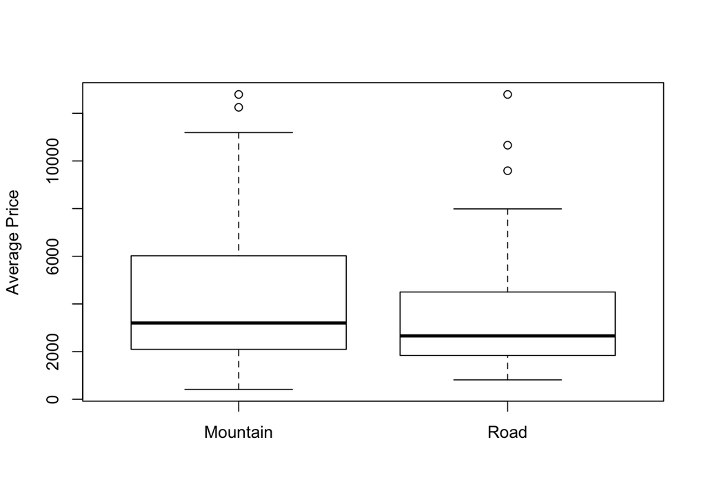

```r
# View average price of different types of bikes
boxplot(df$price~df$category1, ylab = "Average Price")
```

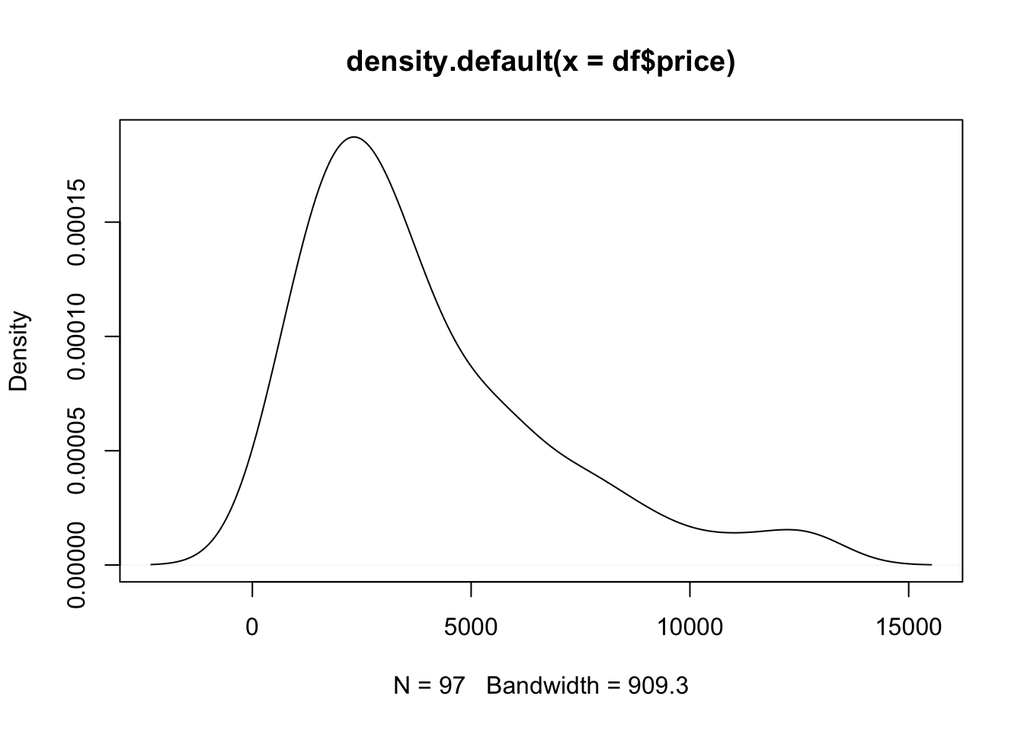

```r
plot(density(df$price))
```

```r
# check skewness
library(moments)
agostino.test(df$price)
```

```
##
##  D'Agostino skewness test
##
## data:  df$price
## skew = 1.2873, z = 4.4714, p-value = 7.772e-06
## alternative hypothesis: data have a skewness
```

```r
# fix positive skew
agostino.test(log(df$price))
```

```
##
##  D'Agostino skewness test
##
## data:  log(df$price)
## skew = -0.29527, z = -1.24450, p-value = 0.2133
## alternative hypothesis: data have a skewness
```

```r
# build model
price_category <- t.test(sqrt(price) ~ category1, data = df)
price_category
```

```
##
##  Welch Two Sample t-test
##
## data:  sqrt(price) by category1
## t = 0.96995, df = 94.792, p-value = 0.3345
## alternative hypothesis: true difference in means is not equal to 0
## 95 percent confidence interval:
##  -4.424787 12.878624
## sample estimates:
## mean in group Mountain     mean in group Road
##               61.10085               56.87393
```

### 4.2. Is the average price of aluminum bike different from carbon bike?

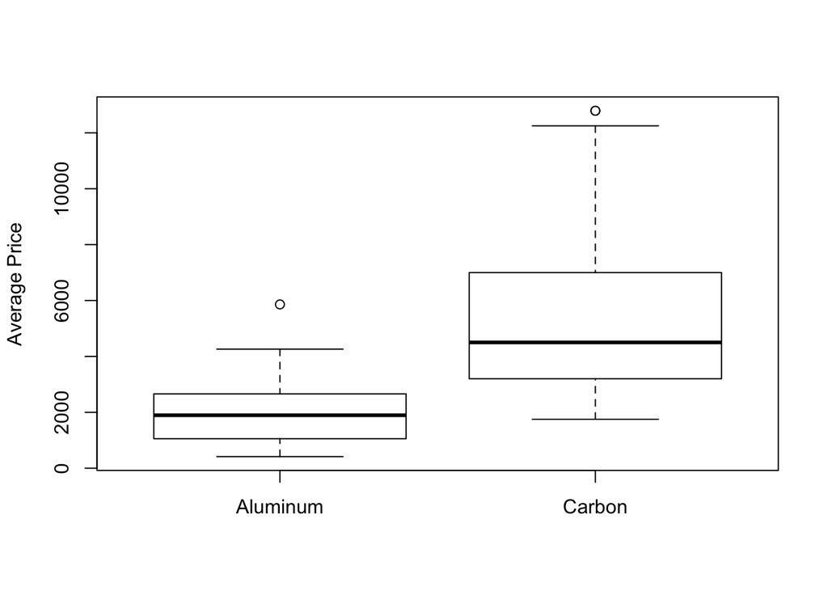

```r
# View average price of different types of bikes
boxplot(df$price~df$frame, ylab = "Average Price")
```

```r
# check distribution

# check skewness
library(moments)
agostino.test(df$price)
```

```
##
##  D'Agostino skewness test
##
## data:  df$price
## skew = 1.2873, z = 4.4714, p-value = 7.772e-06
## alternative hypothesis: data have a skewness
```

```r
# fix positive skew
agostino.test(log(df$price))
```

```
##
##  D'Agostino skewness test
##
## data:  log(df$price)
## skew = -0.29527, z = -1.24450, p-value = 0.2133
## alternative hypothesis: data have a skewness
```

```r
# build model
price_category <- t.test(log(price) ~ frame, data = df)
price_category
```

```
##
##  Welch Two Sample t-test
##
## data:  log(price) by frame
## t = -8.4942, df = 77.67, p-value = 1.067e-12
## alternative hypothesis: true difference in means is not equal to 0
## 95 percent confidence interval:
##  -1.2545054 -0.7780807
## sample estimates:
## mean in group Aluminum   mean in group Carbon
##               7.425063               8.441356
```

The p-value is smaller than 0.05, so the difference of price between aluminum bike and carbon bike is significant. From the boxplot we see the average of carbon bike is higher. Therefore we can confidently conclude that the average price of bikes made of carbon is higher than those made in aluminum.

### 4.3. Which model has the highest market share?

To find out which model has the highest market share, we need to find the average market share of each model among all the 30 stores.

For the purpose of my research, I will add a new colomn named ‘Avg’. It is the average market share of a bike amoung all the 30 stores in the data set. The exact market share should be the average market share weighted by each store’s number of bikes sale. But because we don’t know the number of bikes sale in each store, we cannot calculate the weighted average. So we will simplify the problem and just calculate the mean of a bike’s market share at each store as the average market share of that model of bike. The average market share will be stored in a new column named “Avg_percentage”. We multiplied 100 to it to make the values in percentage.

```r
library(tidyverse)
df <- df %>%
  mutate(Avg_percentage = select(., Albuquerque.Cycles:Wichita.Speed) %>% rowSums(na.rm = TRUE)*100/30)
```

Then we can find which bike has highest market share by sorting

```r
# sort data by average market share
sorted_mkt <- df[order(df$Avg_percentage, decreasing = TRUE),]

top_n(sorted_mkt[, c("model", "category1", "price", "Avg_percentage" )], 10)
```

```
##                       model category1 price Avg_percentage
## 1                CAAD12 Red      Road  3200       1.674347
## 2             Slice Ultegra      Road  2700       1.671707
## 3    Supersix Evo Ultegra 3      Road  3200       1.633026
## 4         Slice Ultegra D12      Road  3200       1.625411
## 5          Trigger Carbon 4  Mountain  3200       1.475469
## 6              Synapse Sora      Road  1030       1.448475
## 7  Synapse Carbon Ultegra 3      Road  3200       1.431630
## 8           CAAD12 Disc 105      Road  1950       1.429969
## 9                CAAD8 Sora      Road  1030       1.415616
## 10                CAAD8 105      Road  1410       1.413049
```

So the top 5 best selling bikes are CAAD12 Red, Slice Ultegra, Supersix Evo Ultegra 3, Slice Ultegra D12 and Trigger Carbon 4. Among the Top 10 best selling bikes, only 1 is a mountain bike; all other 9 bikes are road bike.

### 4.4 Can we predict market share by price?

We need to build a regression model to find the relation ship between market share and price.

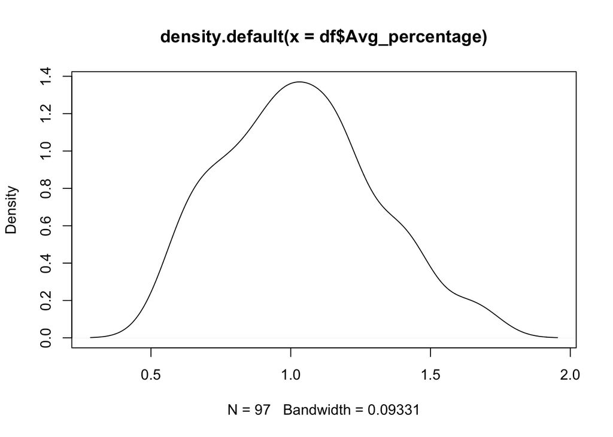

```r
# Distribution of dependent variable
plot(density(df$Avg_percentage))
```

```r
agostino.test(df$Avg_percentage)
```

```
##
##  D'Agostino skewness test
##
## data:  df$Avg_percentage
## skew = 0.3105, z = 1.3064, p-value = 0.1914
## alternative hypothesis: data have a skewness
```

```r
agostino.test(log(df$price))
```

```
##
##  D'Agostino skewness test
##
## data:  log(df$price)
## skew = -0.29527, z = -1.24450, p-value = 0.2133
## alternative hypothesis: data have a skewness
```

The dependent variable Avg_percentage is normally distributed and it does not has skewness. We already know the predictor price has positive skew and we can fix it by taking log.

Next we need to identify the relationships visually.

```r
# identify relationship between predictor and dependent variable
library(car)
```

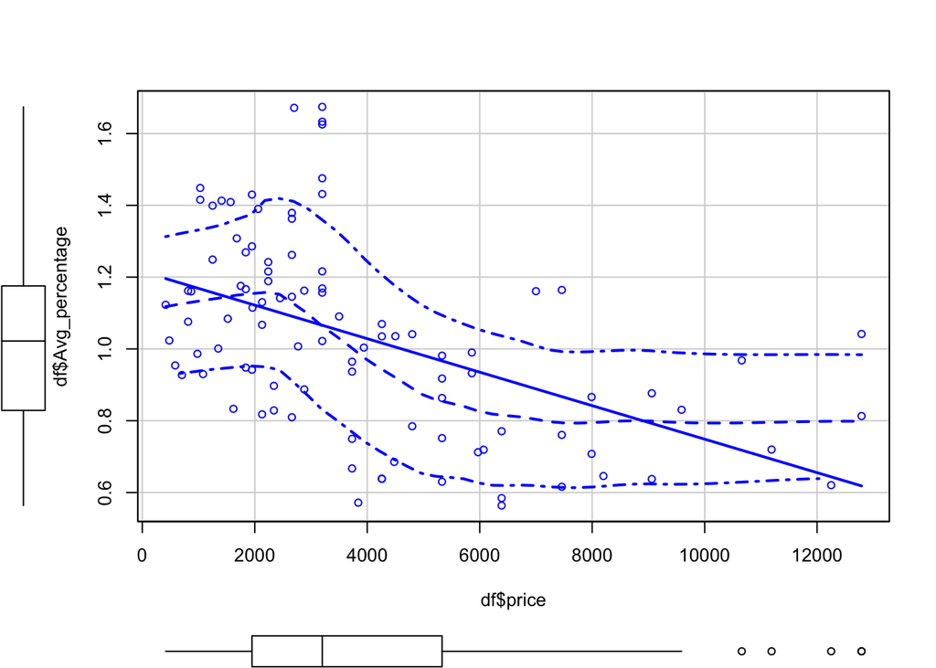

```r
scatterplot(df$price, df$Avg_percentage)
```

Now we can build a linear regression model:

```r
# linear regression model
mkt_model <- lm(df$Avg_percentage ~ df$price)
summary(mkt_model)
```

```
##
## Call:
## lm(formula = df$Avg_percentage ~ df$price)
##
## Residuals:
##      Min       1Q   Median       3Q      Max
## -0.46452 -0.18330 -0.00911  0.13957  0.60823
##
## Coefficients:
##               Estimate Std. Error t value Pr(>|t|)
## (Intercept)  1.216e+00  4.103e-02  29.627  < 2e-16 ***
## df$price    -4.668e-05  8.410e-06  -5.551 2.57e-07 ***
## ---
## Signif. codes:  0 '***' 0.001 '**' 0.01 '*' 0.05 '.' 0.1 ' ' 1
##
## Residual standard error: 0.2367 on 95 degrees of freedom
## Multiple R-squared:  0.2449, Adjusted R-squared:  0.2369
## F-statistic: 30.81 on 1 and 95 DF,  p-value: 2.57e-07
```

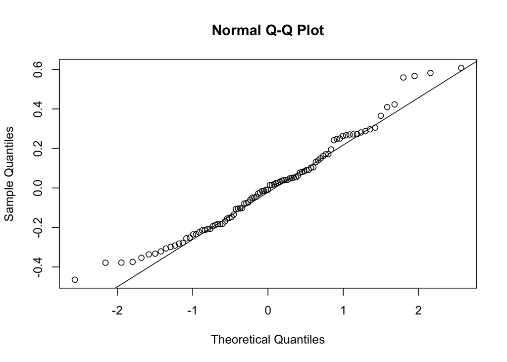

```r
# check residuals
qqnorm(mkt_model$residuals)
qqline(mkt_model$residuals)
```

```r
shapiro.test(mkt_model$residuals)
```

```
##
##  Shapiro-Wilk normality test
##
## data:  mkt_model$residuals
## W = 0.97563, p-value = 0.06781
```

So we found price has negative influence on market share, and the effect is significant (p < 0.05). We also see the residuls of the model is fine but it’s worthing noting that the p-value is very close to 0.05. Therefore we can conclude that lower the price of a bike will enlarge its market share.

## 5. Summary of findings

Through the research on bike market, we raised 4 questions and managed to find the answers by analyzing the data from bike vendors.

We found the average prices of Mountain bikes and Road bikes are not significantly different. But the material of the bike does have significant influence on bikes price; the average price of bikes made of carbon is higher than the average price of those made of aluminum.

In addition, we figured out that the top 5 best selling bikes amoung the vendors in our dataset. We also found that among the Top 10 best selling bikes, only 1 is a mountain bike; all other 9 bikes are road bike.

Further more, we analyzed the relationship between bike’s price and market share by building a regression model. According to our model, price and market share have negative relation; lower the price of a bike will enlarge its market share.